# Bevan Joubert

### Deliverable 3 - Models

```python
# First Create some functions which will help the analysis.

# A function to plote the confusion matrix.
def plotConfusionMatrix(model, xTest, yTest):
    yPredict = model.predict(xTest)
    cm=metrics.confusion_matrix(yTest, yPredict)
    sns.heatmap(cm, annot=True,  fmt='g', xticklabels = [0,1] , yticklabels = [0,1])
    plt.ylabel('Observed')
    plt.xlabel('Predicted')
    plt.show()

# A function to plot the yeelowbrick library visulizations.
def plotYellowbrickVis(model, xTrain, xTest, yTrain, yTest):
    classRep = ClassificationReport(model)
    classRep.fit(xTrain, yTrain)
    classRep.score(xTest, yTest)
    classRep.show()

    roc = ROCAUC(model)
    roc.fit(xTrain, yTrain)
    rocScore = roc.score(xTest, yTest)
    roc.show()

# A function to calculate and return all the performance metrics.
def getMetrics(modelName, model, xTrain, xTest, yTrain, yTest):
    ''' Returns a series which can be appended to a dataframe.'''
    yPred = model.predict(xTest)
    metricsDict = {'Train Accuracy':round(model.score(xTrain, yTrain), 4),
                    'Test Accuracy':round(model.score(xTest, yTest), 4),
                    'Recall':round(recall_score(yTest, yPred), 4),
                    'Precision':round(precision_score(yTest, yPred), 4),
                    'F1 Score':round(f1_score(yTest, yPred), 4),
                    'AUC Score':round(roc_auc_score(yTest, yPred), 4)}
    metricsSeries = pd.Series(name=modelName, data=metricsDict)
    return metricsSeries

def appendMetrics(metrics_df, metrics_series, aucMicro, aucMacro):
    metrics_series['AUC Micro'] = aucMicro
    metrics_series['AUC Macro'] = aucMacro
    metrics_df = results_df.append(metrics_series)
    metrics_df.drop_duplicates(inplace=True)
    return metrics_df
```

#### Logistic Regression

```python
# Use Logistic Regression to predict the outcome.
logReg = LogisticRegression(solver='liblinear', random_state = 5)
# Fit the training data to the model.
logReg.fit(X_train, y_train)
# Predict the outcome of the test data.
y_pred = logReg.predict(X_test) # Get the prediction based on a 0.5 probability.
y_prob = logReg.predict_proba(X_test) # Get the probability.
```

```python
# View the coefficients and the intercept.
coefficients_df = pd.DataFrame(logReg.coef_)
coefficients_df['Intercept'] = logReg.intercept_
coefficients_df
```

|  | 0 | 1 | 2 | 3 | 4 | 5 | 6 | 7 | 8 | 9 | 10 | 11 | 12 | 13 | 14 | 15 | 16 | 17 | 18 | 19 | 20 | 21 | 22 | 23 | 24 | 25 | 26 | 27 | 28 | … |
| --- | --- | --- | --- | --- | --- | --- | --- | --- | --- | --- | --- | --- | --- | --- | --- | --- | --- | --- | --- | --- | --- | --- | --- | --- | --- | --- | --- | --- | --- | --- |
| 0 | -0.0110 | -0.0559 | 0.0000 | -0.8522 | -0.5722 | 0.0039 | -0.0994 | -0.0016 | -0.0008 | -0.4540 | -0.2138 | -0.1903 | -0.0560 | 0.4727 | -0.1449 | -0.2344 | 0.2177 | -0.1914 | -0.0723 | -0.0306 | -0.3942 | -0.1074 | -0.1206 | 0.0221 | 0.0519 | 0.0388 | -1.0968 | -0.1639 | 1.6704 | … |

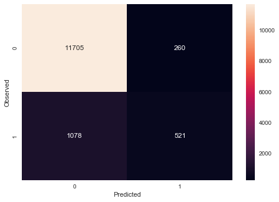

```python
# Plot the confusion matrix.
plotConfusionMatrix(logReg, X_test, y_test)
```

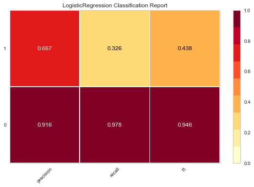

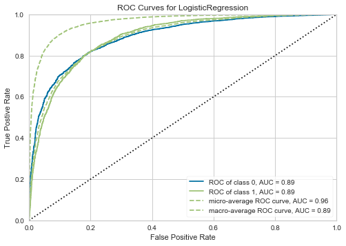

```python
# Visualise the model performance with the yellowbrick library.
plotYellowbrickVis(logReg, X_train, X_test, y_train, y_test)
```

```python
# Create a dataframe to store and compare results.b
results_df = pd.DataFrame(columns=['Train Accuracy', 'Test Accuracy', 'Recall', 'Precision', 'F1 Score', 'AUC Score', 'AUC Micro', 'AUC Macro'])
results = getMetrics("Logistic Regression", logReg, X_train, X_test, y_train, y_test)
results['AUC Micro'] = 0.96
results['AUC Macro'] = 0.89
results_df = results_df.append(results)
results_df
```

|  | Train Accuracy | Test Accuracy | Recall | Precision | F1 Score | AUC Score | AUC Micro | AUC Macro |
| --- | --- | --- | --- | --- | --- | --- | --- | --- |
| Logistic Regression | 0.8991 | 0.9014 | 0.3258 | 0.6671 | 0.4378 | 0.6520 | 0.9600 | 0.8900 |

#### Decision Tree

```python
# Make a Decision Tree with the same data as the Logistic Regression.
dTree = DecisionTreeClassifier(random_state=5)
dTree.fit(X_train, y_train)
print("Training Accuracy: {:.2f}".format(dTree.score(X_train, y_train)))
print("Test Accuracy: {:.2f}".format(dTree.score(X_test, y_test)))
```

```
Training Accuracy: 1.00
Test Accuracy: 0.86
```

```python
# Slightly overfit, try adjusting a few parameters.
dTree = DecisionTreeClassifier(criterion='gini', max_depth=6, random_state=5)
dTree.fit(X_train, y_train)
print("Training Accuracy: {:.2f}".format(dTree.score(X_train, y_train)))
print("Test Accuracy: {:.2f}".format(dTree.score(X_test, y_test)))
```

```
Training Accuracy: 0.91
Test Accuracy: 0.90
```

```python
# View the feature importances.
dTreeImp = pd.DataFrame(dTree.feature_importances_, columns = ["Imp"], index = X_train.columns)
dTreeImp.transpose()
```

|  | age | default | balance | housing | loan | duration | campaign | pdays | previous | job_blue-collar | job_entrepreneur | job_housemaid | job_management | job_retired | job_self-employed | job_services | job_student | job_technician | job_unemployed | job_unknown | marital_married | marital_single | education_secondary | education_tertiary | education_unknown | contact_telephone | contact_unknown | poutcome_other | poutcome_success | … |
| --- | --- | --- | --- | --- | --- | --- | --- | --- | --- | --- | --- | --- | --- | --- | --- | --- | --- | --- | --- | --- | --- | --- | --- | --- | --- | --- | --- | --- | --- | --- |
| Imp | 0.0545 | 0.0000 | 0.0051 | 0.0410 | 0.0000 | 0.5378 | 0.0007 | 0.0459 | 0.0010 | 0.0006 | 0.0007 | 0.0000 | 0.0005 | 0.0000 | 0.0000 | 0.0000 | 0.0000 | 0.0000 | 0.0000 | 0.0000 | 0.0036 | 0.0020 | 0.0012 | 0.0000 | 0.0007 | 0.0000 | 0.0218 | 0.0000 | 0.2828 | … |

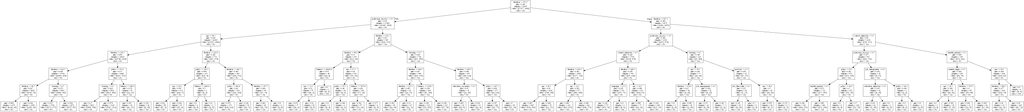

```python
# Draw the Decision Tree.
train_char_label = ['No', 'Yes']
dTreeFile = open('dTree.dot','w')
dot_data = tree.export_graphviz(dTree, out_file=dTreeFile, feature_names = list(X_train), class_names = list(train_char_label))
dTreeFile.close()

retCode = system("dot -Tpng dTree.dot -o dTree.png")
if(retCode>0):
    print("system command returning error: "+str(retCode))
else:
    display(Image("dTree.png"))
```

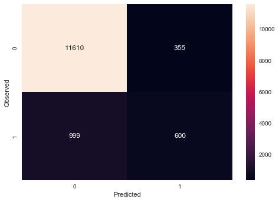

```python
plotConfusionMatrix(dTree, X_test, y_test)
```

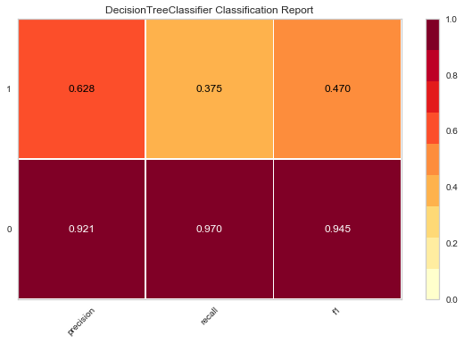

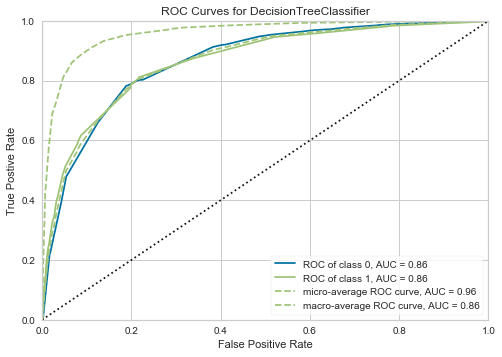

```python
# Visualise the metrics with the yellowbrick library
plotYellowbrickVis(dTree, X_train, X_test, y_train, y_test)
```

```python
# Get all the metrics and add it to the results dataframe.
results = getMetrics("Decision Tree", dTree, X_train, X_test, y_train, y_test)
results['AUC Micro'] = 0.96
results['AUC Macro'] = 0.86
results_df = results_df.append(results)
results_df.drop_duplicates(inplace=True)
results_df
```

|  | Train Accuracy | Test Accuracy | Recall | Precision | F1 Score | AUC Score | AUC Micro | AUC Macro |
| --- | --- | --- | --- | --- | --- | --- | --- | --- |
| Logistic Regression | 0.8991 | 0.9014 | 0.3258 | 0.6671 | 0.4378 | 0.6520 | 0.9600 | 0.8900 |
| Decision Tree | 0.9067 | 0.9002 | 0.3752 | 0.6283 | 0.4699 | 0.6728 | 0.9600 | 0.8600 |

#### Logistic Regression and Decision Tree Observations

- Both models yield very similar results and both have a high accuracy.
- However, since there is a large class imbalance, the accuracy is misleading and should not be used as the primary metric.
- We want to miss out on as few actual clients as possible, while cutting down marketing to clients who will not accept.
- Therefore, I would say that the recall and precision are more important.
- The higher the recall, the more clients who will actually accept the offer are contacted, therefore increasing revenue.
- The higher the precision, the fewer clients who will not accept the offer are contacted, therefore decreasing marketing costs.
- Therefore, both recall and precision are important metrics for this problem.
- The F1 score reflects how good both precision and acuuracy are combined.
- Therefore, a high F1 score means that we are acheiving both our goals of increasing revenue and cutting costs.
- Thus, I would say that F1 score is the most important metric for this application.
- When F1 scores between models are close, we should weigh potential income to marketing costs and decide which is more important.
- I would ay that getting a few more clients will generate more revenue than contacting a few more clients would cost.
- Therefore, for models with close F1 scores, I would take the one with higher recall.
- Thus Between the above models, I would choose the decision tree.

### Ensemble Models

#### Bagging Classifier

```python
# Let's try a bagging classifier based on the decision tree.
bgcl = BaggingClassifier(base_estimator=dTree, n_estimators=50, random_state=5)
bgcl.fit(X_train, y_train)
print("Training Accuracy: {:.2f}".format(bgcl.score(X_train, y_train)))
print("Test Accuracy: {:.2f}".format(bgcl.score(X_test, y_test)))
```

```
Training Accuracy: 0.91
Test Accuracy: 0.90
```

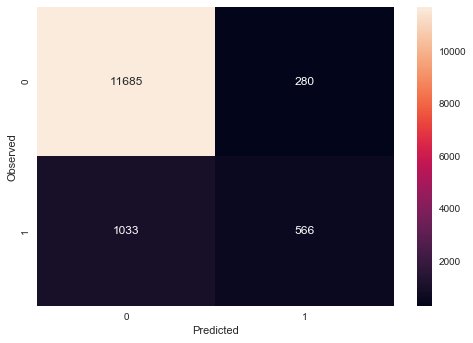

```python
# Plot the confusion matrix.
plotConfusionMatrix(bgcl, X_test, y_test)
```

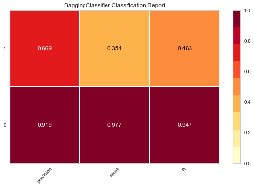

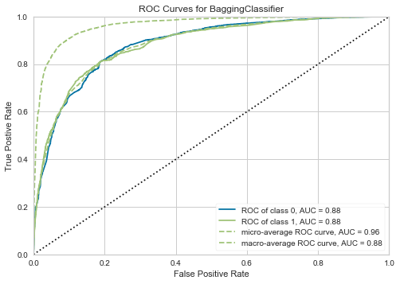

```python
# Plot the yellowbrick visualizations.
plotYellowbrickVis(bgcl, X_train, X_test, y_train, y_test)
```

```python
# Add all the metrics of the bagging classifier to the results dataframe.
results = getMetrics("Bagging Classifier", bgcl, X_train, X_test, y_train, y_test)
results_df = appendMetrics(results_df, results, 0.96, 0.88)
results_df
```

|  | Train Accuracy | Test Accuracy | Recall | Precision | F1 Score | AUC Score | AUC Micro | AUC Macro |
| --- | --- | --- | --- | --- | --- | --- | --- | --- |
| Logistic Regression | 0.8991 | 0.9014 | 0.3258 | 0.6671 | 0.4378 | 0.6520 | 0.9600 | 0.8900 |
| Decision Tree | 0.9067 | 0.9002 | 0.3752 | 0.6283 | 0.4699 | 0.6728 | 0.9600 | 0.8600 |
| Bagging Classifier | 0.9088 | 0.9032 | 0.3540 | 0.6690 | 0.4630 | 0.6653 | 0.9600 | 0.8800 |

#### Random Forest

```python
# Now try random a random forest classifier.
rfcl = RandomForestClassifier(n_estimators=50, random_state=5, max_features=20)
rfcl.fit(X_train, y_train)
print("Training Accuracy: {:.2f}".format(rfcl.score(X_train, y_train)))
print("Test Accuracy: {:.2f}".format(rfcl.score(X_test, y_test)))
```

```
Training Accuracy: 1.00
Test Accuracy: 0.90
```

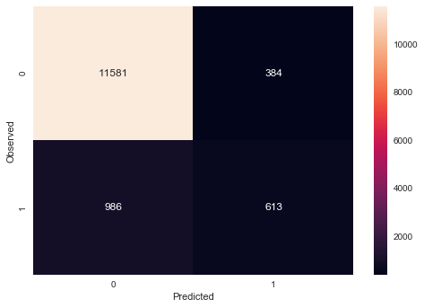

```python
# Plot the confusion matrix.
plotConfusionMatrix(rfcl, X_test, y_test)
```

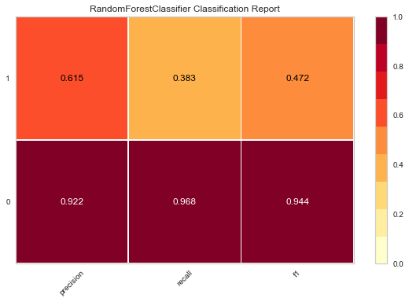

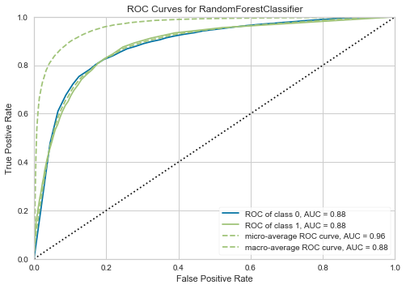

```python
# Plot the yellowbrick visualizations.
plotYellowbrickVis(rfcl, X_train, X_test, y_train, y_test)
```

```python
# Get all the metrics and add it to the results dataframe.
results = getMetrics("Random Forest", rfcl, X_train, X_test, y_train, y_test)
results_df = appendMetrics(results_df, results, 0.96, 0.88)
results_df
```

|  | Train Accuracy | Test Accuracy | Recall | Precision | F1 Score | AUC Score | AUC Micro | AUC Macro |
| --- | --- | --- | --- | --- | --- | --- | --- | --- |
| Logistic Regression | 0.8991 | 0.9014 | 0.3258 | 0.6671 | 0.4378 | 0.6520 | 0.9600 | 0.8900 |
| Decision Tree | 0.9067 | 0.9002 | 0.3752 | 0.6283 | 0.4699 | 0.6728 | 0.9600 | 0.8600 |
| Bagging Classifier | 0.9088 | 0.9032 | 0.3540 | 0.6690 | 0.4630 | 0.6653 | 0.9600 | 0.8800 |
| Random Forest | 0.9997 | 0.8990 | 0.3834 | 0.6148 | 0.4723 | 0.6756 | 0.9600 | 0.8800 |

```python
# Random Forest has the lowest accuracy so far, but the highest F1 score.
```

#### Adaptive Boosting

```python
# We are done with bagging clasifiers, let's try some boosting classifiers. Adaptive Boosting is first up.
abcl = AdaBoostClassifier(n_estimators=50, random_state=5)
abcl.fit(X_train, y_train)
print("Training Accuracy: {:.2f}".format(abcl.score(X_train, y_train)))
print("Test Accuracy: {:.2f}".format(abcl.score(X_test, y_test)))
```

```
Training Accuracy: 0.90
Test Accuracy: 0.90
```

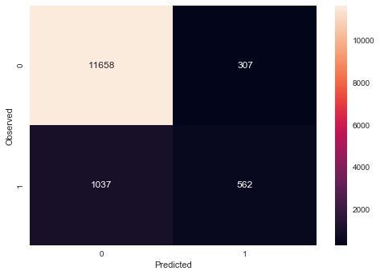

```python
# Plot the confusion matrix.
plotConfusionMatrix(abcl, X_test, y_test)
```

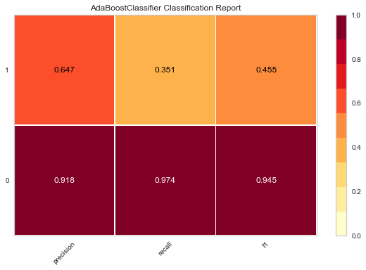

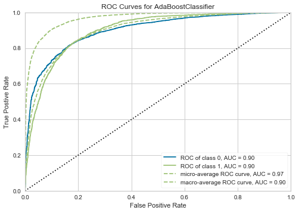

```python
# Plot the yellowbrick visualizations.
plotYellowbrickVis(abcl, X_train, X_test, y_train, y_test)
```

```python
# Get all the metrics and add it to the results dataframe.
results = getMetrics("Adaptive Boosting", abcl, X_train, X_test, y_train, y_test)
results_df = appendMetrics(results_df, results, 0.97, 0.90)
results_df
```

|  | Train Accuracy | Test Accuracy | Recall | Precision | F1 Score | AUC Score | AUC Micro | AUC Macro |
| --- | --- | --- | --- | --- | --- | --- | --- | --- |
| Logistic Regression | 0.8991 | 0.9014 | 0.3258 | 0.6671 | 0.4378 | 0.6520 | 0.9600 | 0.8900 |
| Decision Tree | 0.9067 | 0.9002 | 0.3752 | 0.6283 | 0.4699 | 0.6728 | 0.9600 | 0.8600 |
| Bagging Classifier | 0.9088 | 0.9032 | 0.3540 | 0.6690 | 0.4630 | 0.6653 | 0.9600 | 0.8800 |
| Random Forest | 0.9997 | 0.8990 | 0.3834 | 0.6148 | 0.4723 | 0.6756 | 0.9600 | 0.8800 |
| Adaptive Boosting | 0.9001 | 0.9009 | 0.3515 | 0.6467 | 0.4554 | 0.6629 | 0.9700 | 0.9000 |

#### Gradient Boosting

```python
# We are done with bagging clasifiers, let's try some boosting classifiers. Adaptive Boosting is first up.
gbcl = GradientBoostingClassifier(n_estimators=50, random_state=5)
gbcl.fit(X_train, y_train)
print("Training Accuracy: {:.2f}".format(gbcl.score(X_train, y_train)))
print("Test Accuracy: {:.2f}".format(gbcl.score(X_test, y_test)))
```

```
Training Accuracy: 0.90
Test Accuracy: 0.90
```

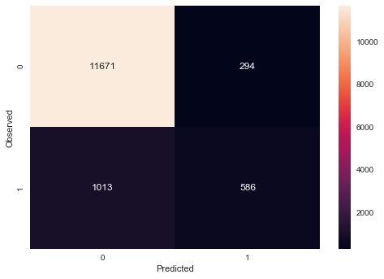

```python
# Plot the confusion matrix.
plotConfusionMatrix(gbcl, X_test, y_test)
```

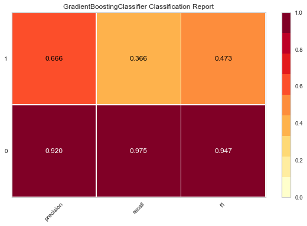

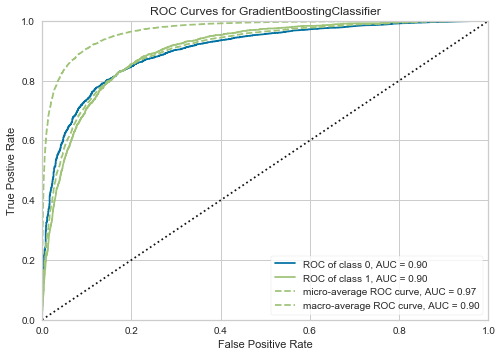

```python
# Plot the yellowbrick visualizations.
plotYellowbrickVis(gbcl, X_train, X_test, y_train, y_test)
```

```python
# Get all the metrics and add it to the results dataframe.
results = getMetrics("Gradient Boosting", gbcl, X_train, X_test, y_train, y_test)
results_df = appendMetrics(results_df, results, 0.97, 0.90)
results_df
```

|  | Train Accuracy | Test Accuracy | Recall | Precision | F1 Score | AUC Score | AUC Micro | AUC Macro |
| --- | --- | --- | --- | --- | --- | --- | --- | --- |
| Logistic Regression | 0.8991 | 0.9014 | 0.3258 | 0.6671 | 0.4378 | 0.6520 | 0.9600 | 0.8900 |
| Decision Tree | 0.9067 | 0.9002 | 0.3752 | 0.6283 | 0.4699 | 0.6728 | 0.9600 | 0.8600 |
| Bagging Classifier | 0.9088 | 0.9032 | 0.3540 | 0.6690 | 0.4630 | 0.6653 | 0.9600 | 0.8800 |
| Random Forest | 0.9997 | 0.8990 | 0.3834 | 0.6148 | 0.4723 | 0.6756 | 0.9600 | 0.8800 |
| Adaptive Boosting | 0.9001 | 0.9009 | 0.3515 | 0.6467 | 0.4554 | 0.6629 | 0.9700 | 0.9000 |
| Gradient Boosting | 0.9049 | 0.9036 | 0.3665 | 0.6659 | 0.4728 | 0.6710 | 0.9700 | 0.9000 |

```python
# Calculate the sum of all the metrics excluding the 'Train Accuracy'. Not that this is something one should neccessarily consider.
results_df['Sum(Train Acc. Excl.)'] = results_df.drop(columns=['Train Accuracy']).sum(axis=1)
results_df
```

|  | Train Accuracy | Test Accuracy | Recall | Precision | F1 Score | AUC Score | AUC Micro | AUC Macro | Sum(Train Acc. Excl.) |
| --- | --- | --- | --- | --- | --- | --- | --- | --- | --- |
| Logistic Regression | 0.8991 | 0.9014 | 0.3258 | 0.6671 | 0.4378 | 0.6520 | 0.9600 | 0.8900 | 4.8341 |
| Decision Tree | 0.9067 | 0.9002 | 0.3752 | 0.6283 | 0.4699 | 0.6728 | 0.9600 | 0.8600 | 4.8664 |
| Bagging Classifier | 0.9088 | 0.9032 | 0.3540 | 0.6690 | 0.4630 | 0.6653 | 0.9600 | 0.8800 | 4.8945 |
| Random Forest | 0.9997 | 0.8990 | 0.3834 | 0.6148 | 0.4723 | 0.6756 | 0.9600 | 0.8800 | 4.8851 |
| Adaptive Boosting | 0.9001 | 0.9009 | 0.3515 | 0.6467 | 0.4554 | 0.6629 | 0.9700 | 0.9000 | 4.8874 |
| Gradient Boosting | 0.9049 | 0.9036 | 0.3665 | 0.6659 | 0.4728 | 0.6710 | 0.9700 | 0.9000 | 4.9498 |

### Conclusion

- The models do not differ greatly from one another.
- The logistic rgression and the decission tree both did remarkably well considering that they are much simpler models than the ensemble models.
- Looking at the sum of the metrics, the Gradient Boosting classifier has the best overall performance by a small margin.
- However, the Random Forest classifier has the highest Recall value.
- This results in the Random Forest classifier having the highest number of true positives and the lowest number of false negatives.
- Thus, the Random Forest Classifier will target the highest number of people who accept the offer.
- Although the Random Forest Classifier does not have the highest Precision value, the precision is comparible to that of the other models.
- A slightly lower precision value will mean that there will be more unsuccessful marketing attempts than other models would have.
- However, I believe that the revenue generated by the higher successes will outweigh the costs of the unsuccessful attempts.
- In Conclusion, the Random Forest classifier is the best model for this business case.